# RT01: Uso do pacote `ggplot2`

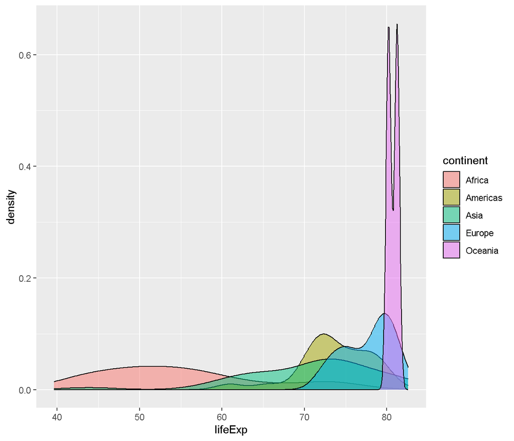

```r
gm.2007 <- filter(gapminder, year == 2007)
ggplot(gm.2007, aes(x = lifeExp)) + geom_density(alpha = 0.5) +
    aes(fill = continent)
```

A densidade está pouco suavizada para a Oceania, pois há apenas dois países nesse grupo. Uma alternativa é aumentar o nível de suavização (será usado `adjust=1.5`).

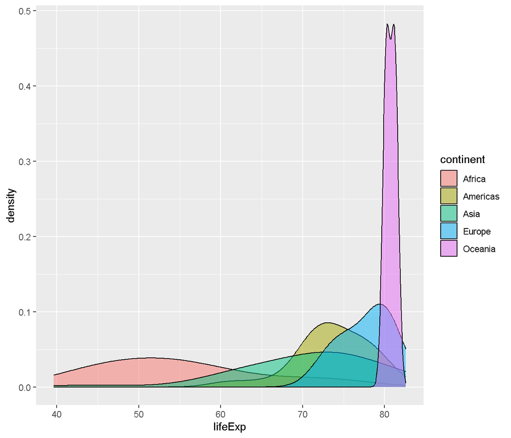

```r
  # densidade por continente aumentando o nível de suavização
ggplot(gm.2007, aes(x = lifeExp)) + geom_density(alpha = 0.5, adjust = 1.5) +
    aes(fill = continent)
```

O nível imposto atuou igualmente em todas as densidades escondendo padrões interessante nos outros continentes (superssuavizou, ou seja, resumiu demais os dados). Uma alternativa seria retirar a Oceania da análise, dado que ela possui poucos dados (apenas dois países) em relação aos demais.

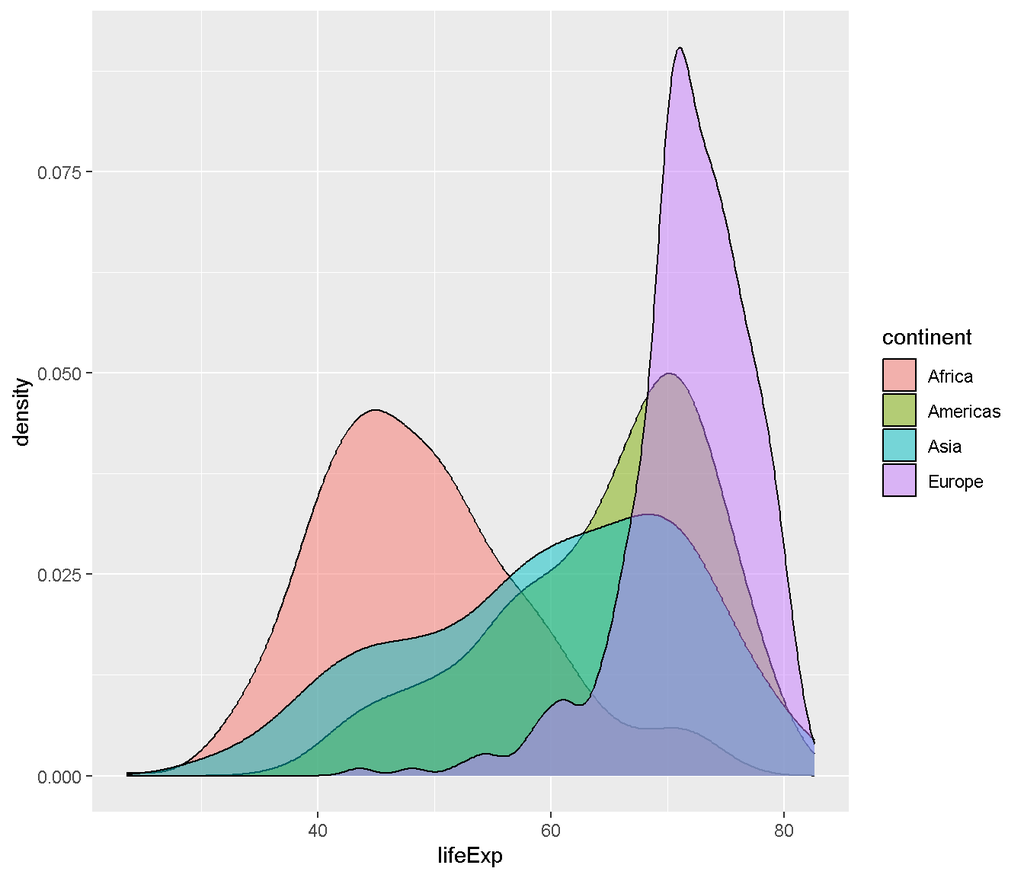

```r
  # densidade por continente sem a Oceania (adjust no valor default)
ggplot(subset(gapminder, continent != "Oceania"), aes(x = lifeExp)) +
    geom_density(alpha = 0.5) +
    aes(fill = continent)
```

Alternativamente, pode-se utilizar *boxplots*, para os quais necessitamos definir uma variável contínua para y e um fator (variável categórica) para x. Abaixo box-plots das expectativas de vida por continente, em 2007.

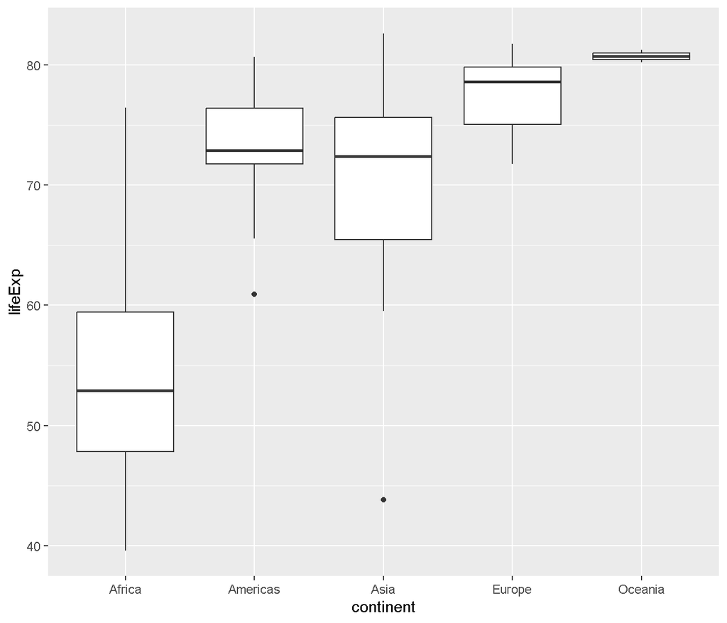

```r
  # box-plot das expectativas de vida em 2007 por continente
ggplot(gm.2007, aes(y = lifeExp, x = continent)) + geom_boxplot()
```

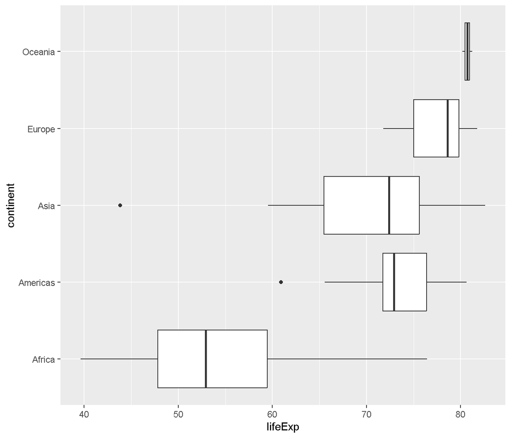

```r
  # box-plot na vertical - aproveitando o último plot
last_plot() + coord_flip()
```

Pode-se tentar ter uma visão dos pontos que formam os box-plots acima, usando-se um *scatterplot*:

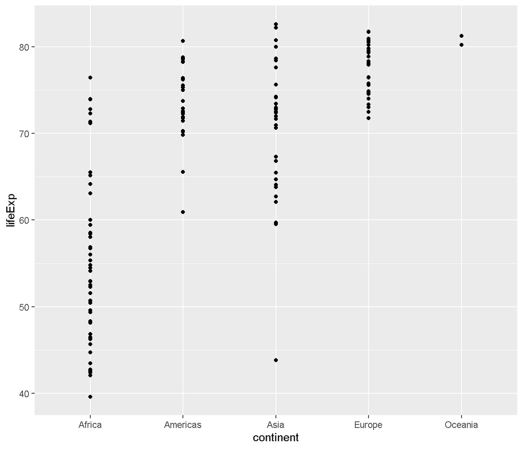

```r
  # scatter plot para os dados
ggplot(gm.2007, aes(y = lifeExp, x = continent)) + geom_point()
```

A visualização melhora se incluirmos uma pequena perturbação (*jittering*) horizontal por meio do comando `position_jitter()`.

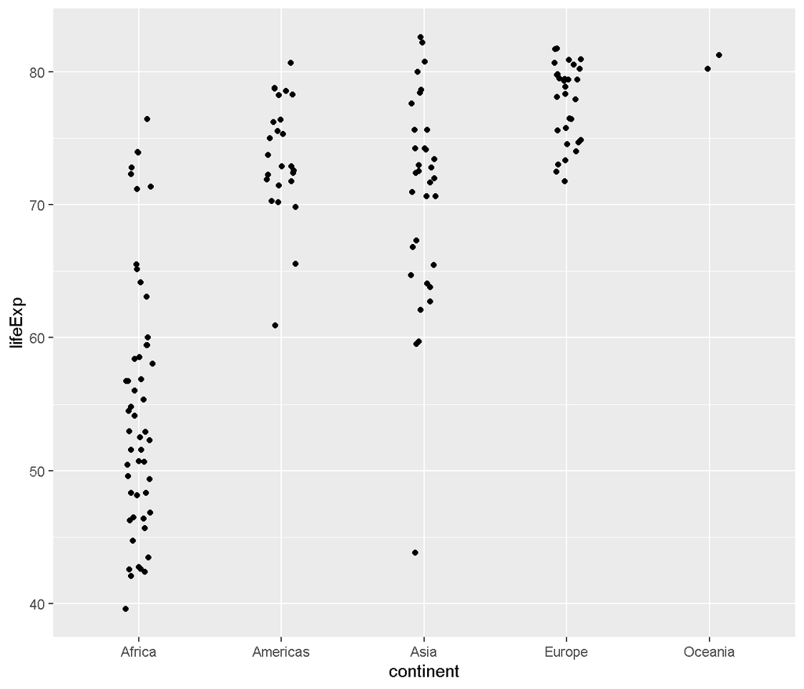

```r
  # jittering horizontal nos dados
ggplot(gm.2007, aes(y = lifeExp, x = continent)) +
    geom_point(position = position_jitter(width = 0.1, height = 0))
```

Uma outra opção interessante para observar a densidade por continente seria plotá-las em gráfico com um painel para cada densidade.

##### Sugestão: Explore a população dos países por continentes

#### Gráficos em painéis

Uma função particularmente importante do `ggplot2` é o faceamento (*faceting*) dos gráficos: a capacidade de fazer uma série de gráficos, condicionados aos valores de variáveis selecionadas.

Por exemplo, em vez de colorir pontos por continente, pode-se separar os continentes em painéis separados. Existem duas funções para isso, `facet_grid()` e `facet_wrap()`.

Aqui estão os dados de expectativa de vida e renda per capita na escala-log, separados por continente, usando-se a função `facet_grid()`.

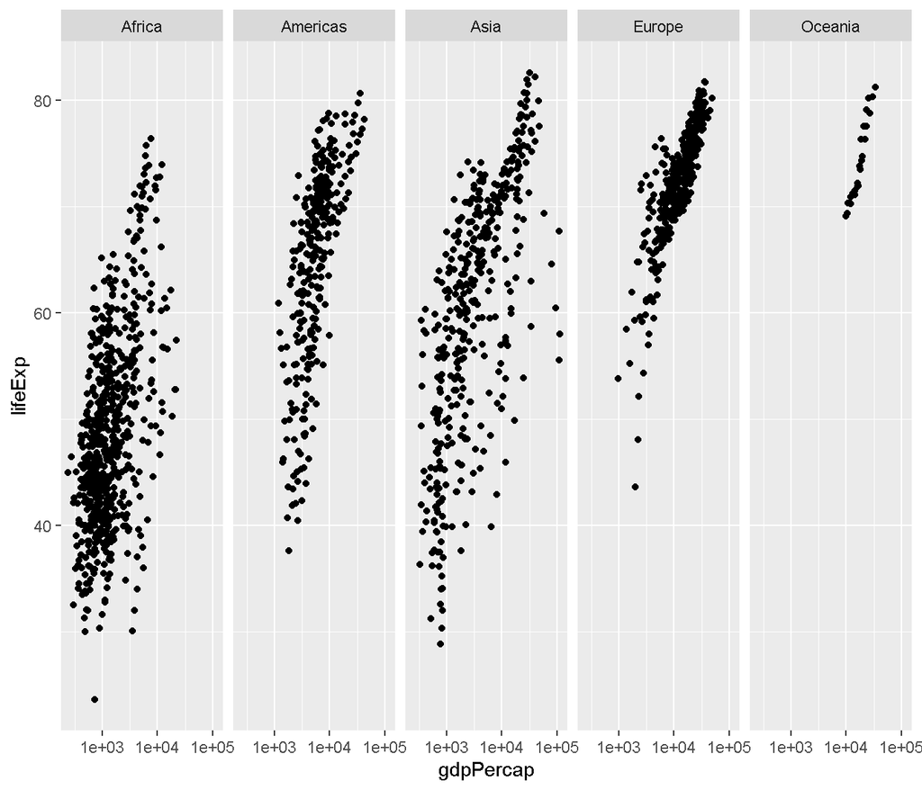

```r
    # diagramas de dispersão em paineis por continentes
p <- ggplot(gapminder, aes(x = gdpPercap, y = lifeExp))
p + geom_point() + scale_x_log10() +
    facet_grid(~ continent)
```

Gráficos dispostos verticalmente. O comando necessita do ponto.

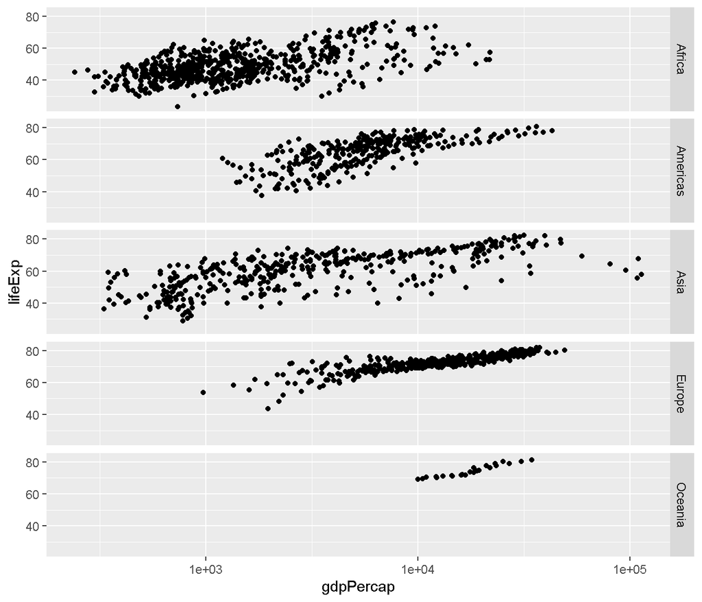

```r
  # paineis dispostos verticalmente
p + geom_point() + scale_x_log10() +
    facet_grid(continent ~ .)
```

Os dados podem ser “embrulhados” (*wrap*), em várias linhas e colunas, usando-se a função `facet_wrap()`.

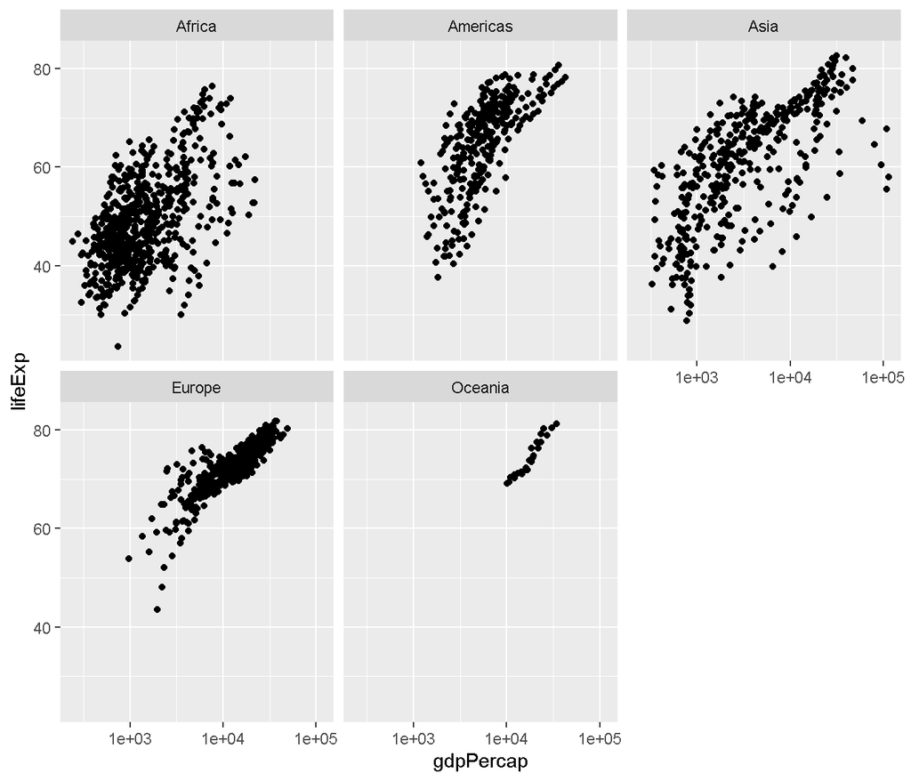

```r
  # paineis por varias linhas e colunas (wrap)
p + geom_point() + scale_x_log10() +
    facet_wrap(~ continent)
```

A disposição dos painéis obtida pela função `facet_wrap()` é particularmente útil se são necessários muitos deles, como por exemplo, quando desja-se a visualização da relação entre a expectativa de vida ao nascer em relação ao log da renda per capita, nos vários valores da variável `year`.

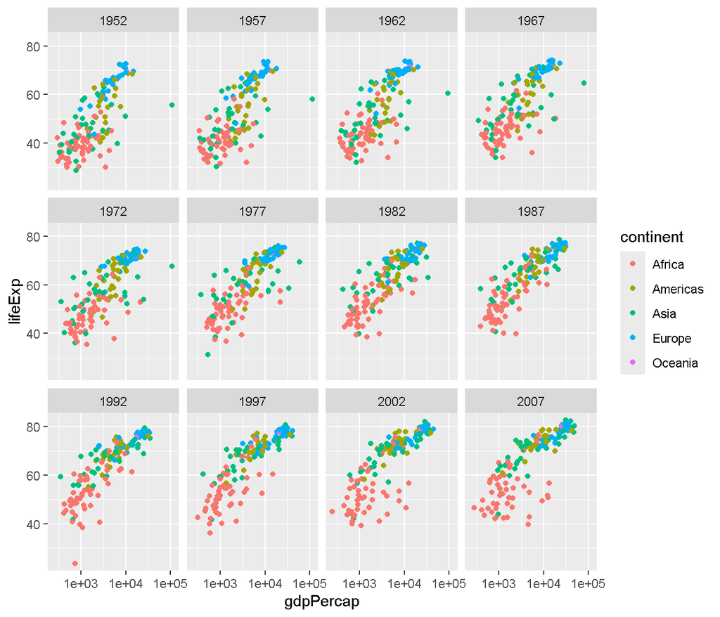

```r
  # painéis de acordo ao fator year (muitos níveis)
p <- ggplot(gapminder, aes(x = gdpPercap, y = lifeExp)) + geom_point() +
    scale_x_log10()
p + aes(color = continent) + facet_wrap(~ year)
```

Pode-se montar os painéis por mais de um fator, como por exemplo com `year` e `continent`:

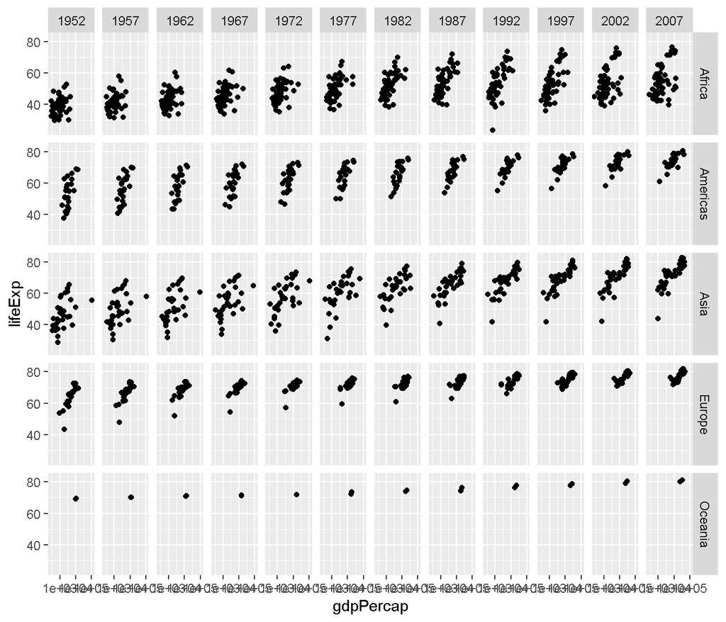

```r
  # paineis de acordo com dois fatores (year e continent)
p + facet_grid(continent ~ year)
```

Uma visualização interessante da relação entre expectativa de vida e log da renda per capita, por ano e continente, seria plotar os diagramas de dispersão dessas variáveis sem a Oceania, já que esse continente tem apenas dois países do conjunto de dados.

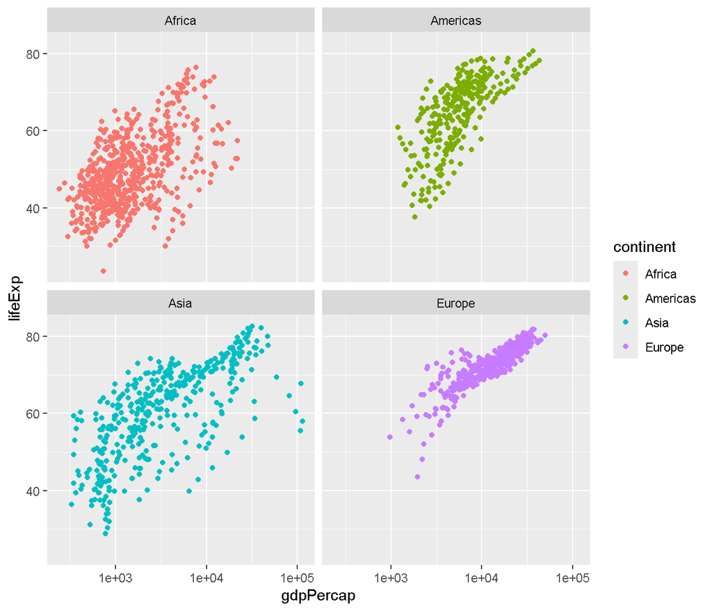

```r
  # paineis sem a oceania - cores por continente
p <- ggplot(subset(gapminder, continent != "Oceania"),
    aes(x = gdpPercap, y = lifeExp))
p + geom_point() + scale_x_log10() + aes(color = continent) +
    facet_wrap(~ continent)
```

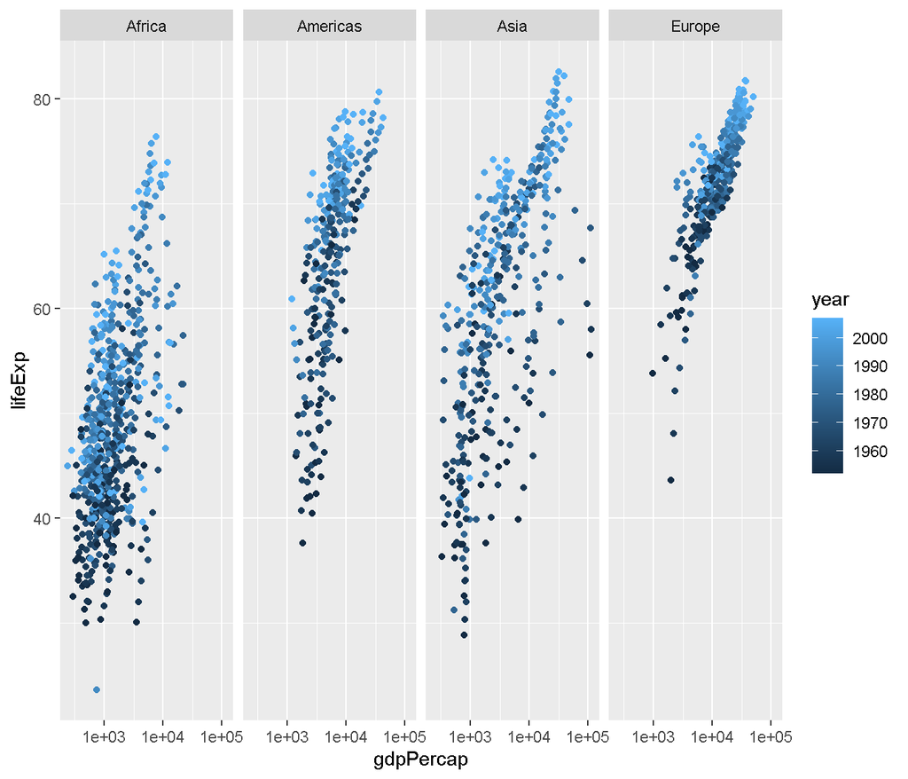

```r
  # paineis verticais com cores por anos
p + geom_point() + scale_x_log10() + aes(color = year) +
    facet_grid(~ continent)
```

#### Diagrama de dispersão condicionados a níveis de variável categórica

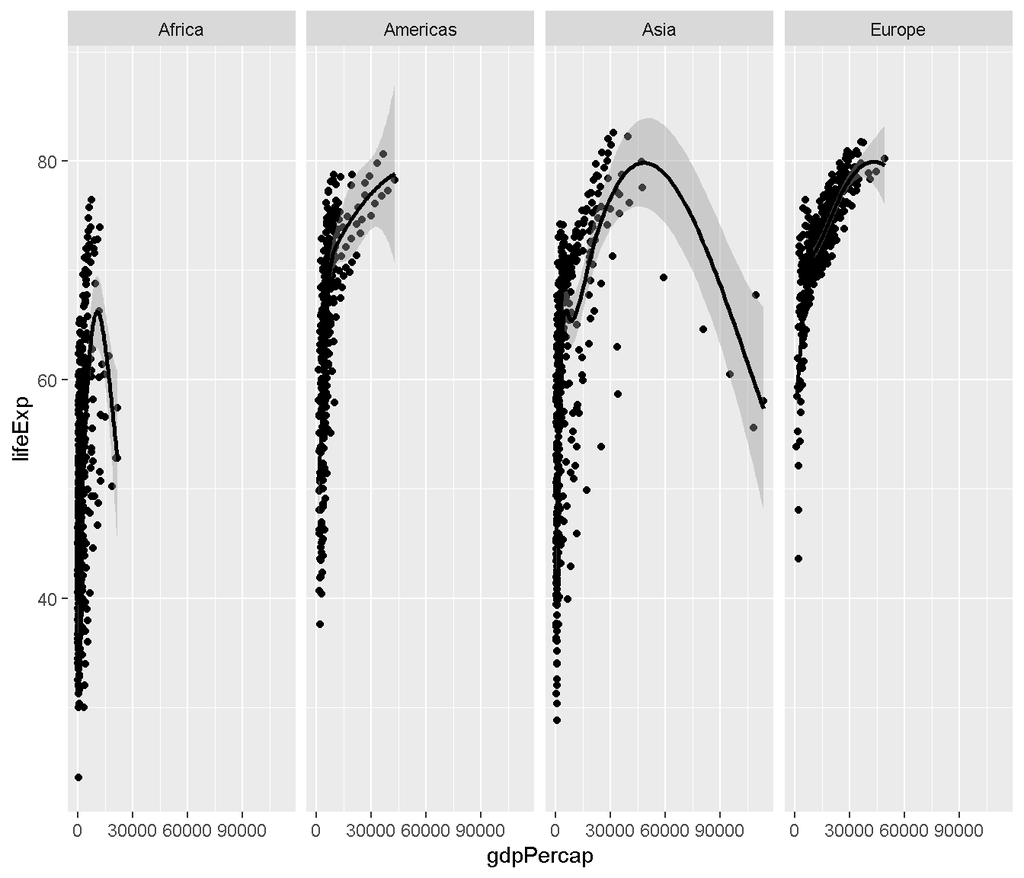

```r
p + geom_point() + geom_smooth(method = "loess", colour = "black") +
    facet_grid(~continent)
```

A função `xyplot`, do pacote `lattice` constrói um gráfico semelhante, embora apresentando apenas os pontos.

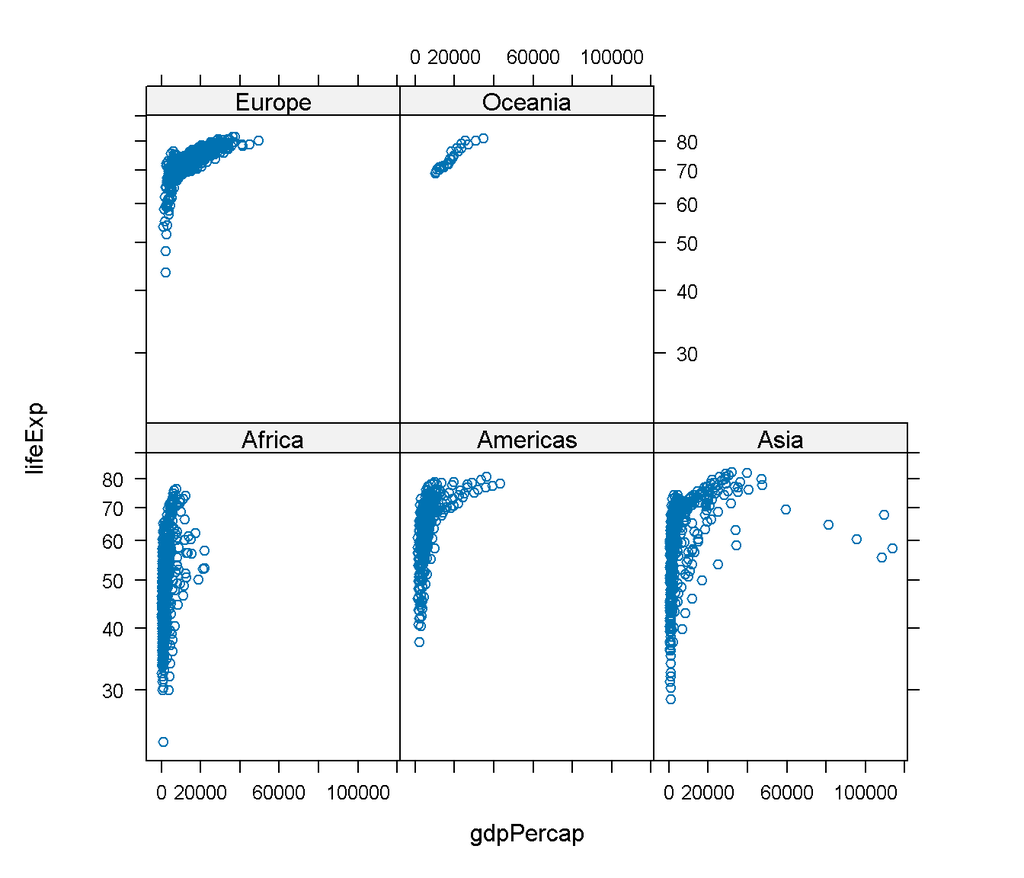

```r
  # gráfico condicionado ao continente, pelo pacote lattice
library(lattice)
xyplot(lifeExp ~ gdpPercap | continent, gapminder,
    scales = list(y = list(log = 10, equispaced.log = FALSE)))
```

O comando `geom_bin2d()` permite apresentar o gráfico com a densidade em cores diferentes por pequenas áreas. (Difícil de obter com o pacote `lattice`.)

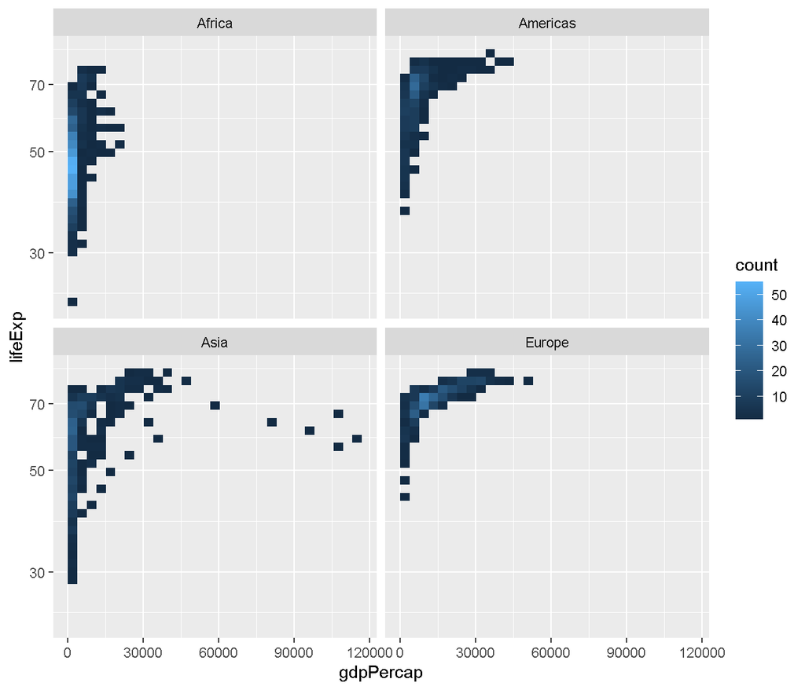

```r
  # scatter plot com cores de acordo com a densidade bivariada.
p + geom_bin2d() + scale_y_log10() + facet_wrap(~continent)
```

#### Figura tipo *stripplot*

Evolução da expectativa de vida ao nascer nos diferentes continentes.

Plot de `lifeExp` vs. year, com cores por continente. Os anos são discretos (5 em 5 anos). Uso dos comandos `ggplot()` e `geom_point`.

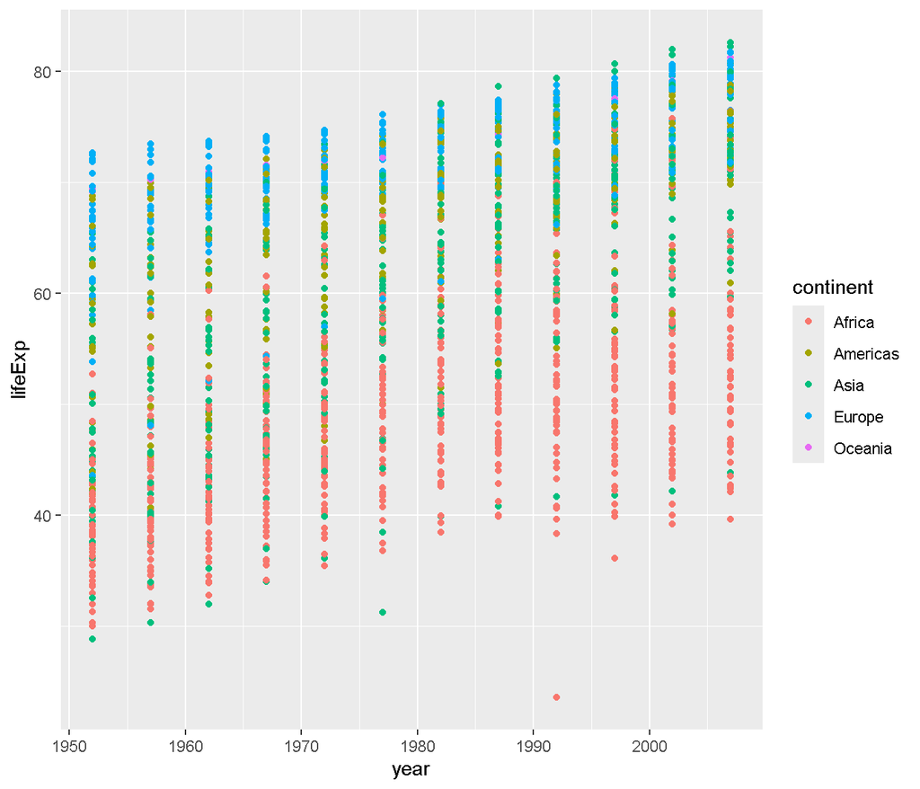

```r
  # plot de expectativa de vida vs. year, com cores por continentes
ggplot(gapminder, aes(x = year, y = lifeExp, color = continent)) + geom_point()
```

Difícil observar o comportamento da expectativa de vida em cada continente. Uso de boxplot pode auxiliar na visualização da evolução da expectativa de vida em cada continente. (Criação de objeto `ggplot`e comando `geom_boxplot()`)

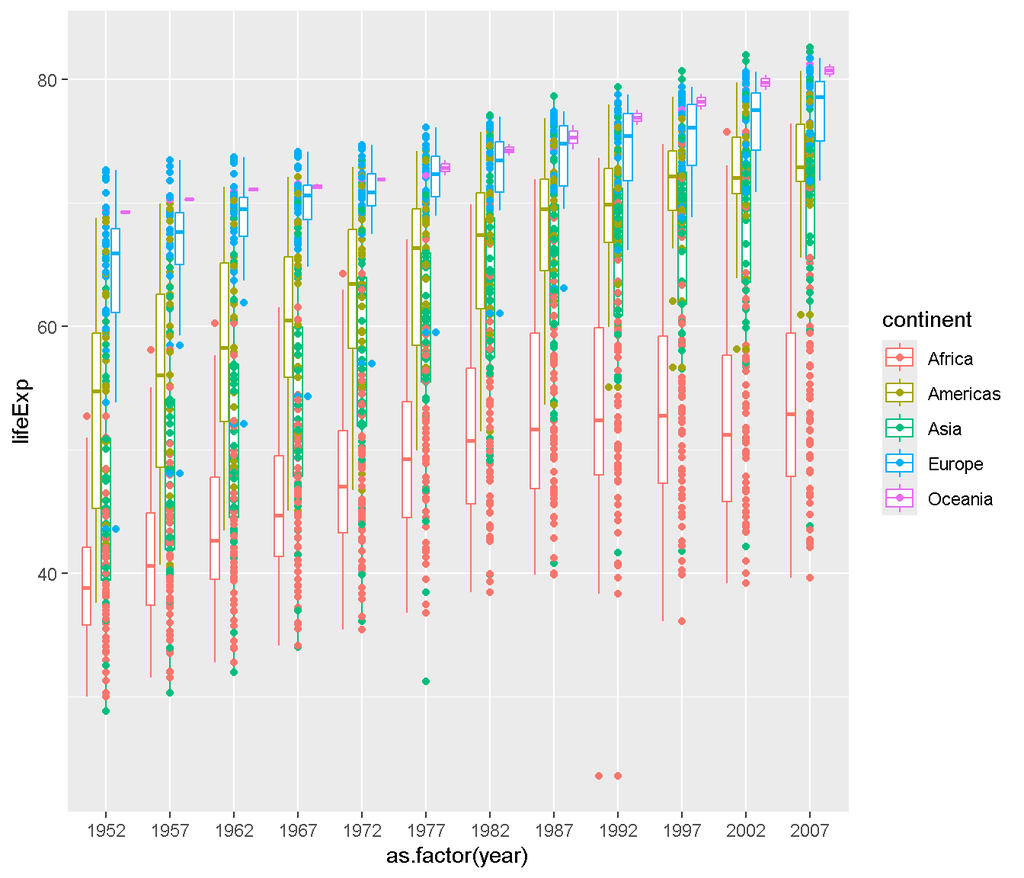

```r
  # objeto ggplot expectativa de vida vs. year, cor por continente
p <- ggplot(gapminder, aes(x = as.factor(year), y = lifeExp, color = continent))   # boxplot por ano, lado a lado
p + geom_boxplot() + geom_point()
```

Visualização ainda não permite perceber claramente o comportamento da expectativa de vida ao longo do tempo. Utilização dos box-plots por anos, em painéis de mesma escala, separados por continente. (Comando `facet_wrap()`)

os box-plots de expectativa de vida ao nascer por continente, em painéis de mesma escala, separados por ano.

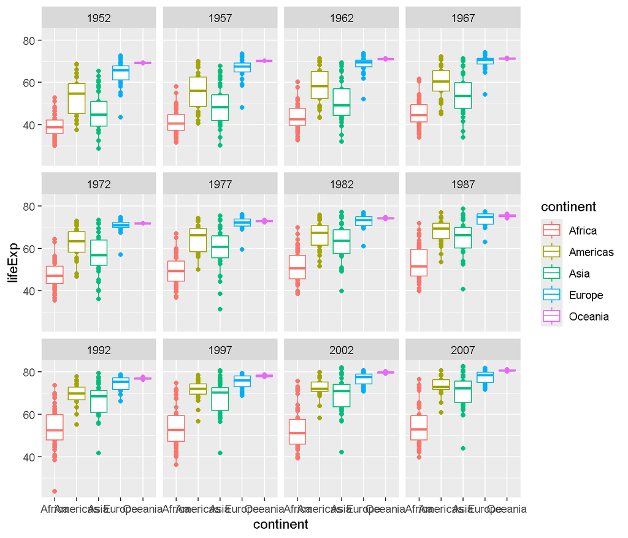

```r
  # boxplot expectativa de vida vs. continente, em painéis separados por ano
p <- ggplot(gapminder, aes(x = continent, y = lifeExp, color = continent))
p + geom_point() + geom_boxplot() + facet_wrap(~ year)
```

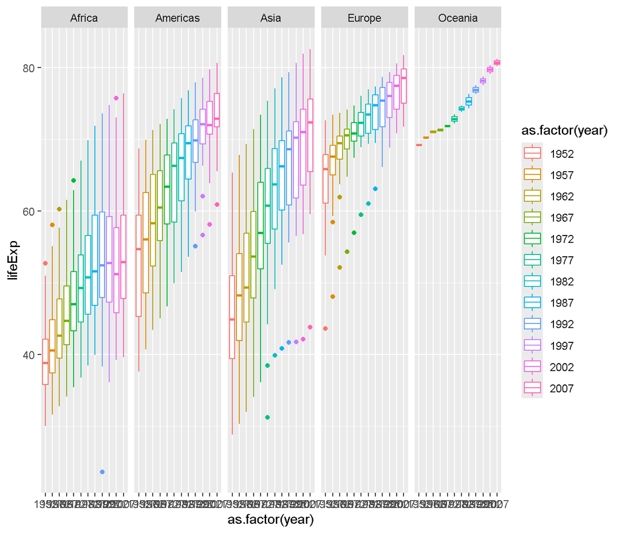

```r
  # boxplot por ano, em paineis separados por continentes
p <- ggplot(gapminder, aes(x = as.factor(year), y = lifeExp,
    color = as.factor(year)))
p + geom_boxplot() + facet_grid(~ continent)
```

#### Temas

Os temas permitem mudar a aparência global de um gráfico. O tema default é `theme_gray()`. Alguns temas também disponíveis: `theme_bw()`, `theme_linedraw()`, etc.

Exemplos de uso de temas na visualização da associação da expectativa de vida com a renda per capita na log-escala, condicionada ao continente. O tema default (`theme_gray()`) tem o seguinte aspecto

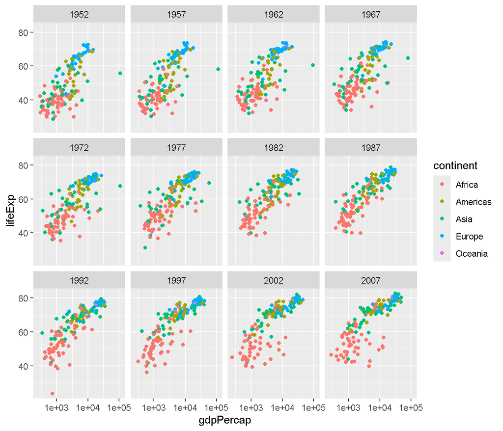

```r
p <- p <- ggplot(gapminder, aes(y = lifeExp, x = gdpPercap))
p + geom_point(aes(colour = continent)) + scale_x_log10() +
    facet_wrap(~ year)
```

Mesmo gráfico, com o tema `theme_bw()`.

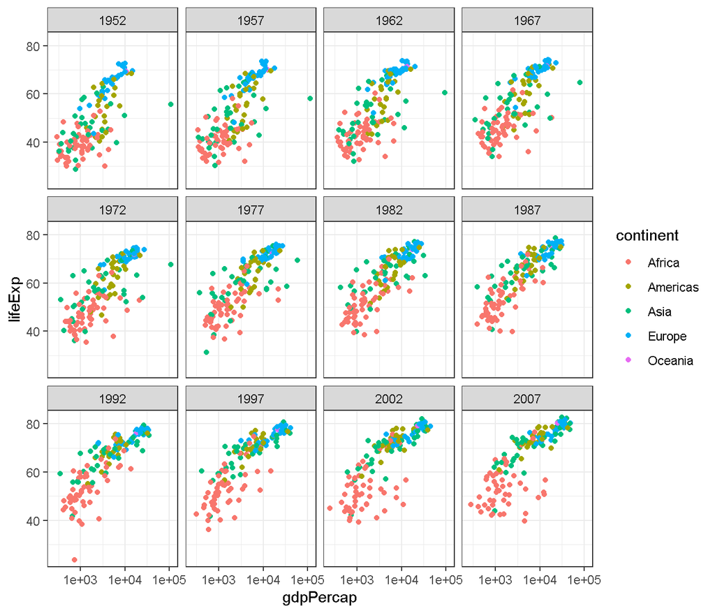

```r
p + geom_point(aes(colour = continent)) + scale_x_log10() +
    facet_wrap(~ year) +
  theme_bw()
```

Mesmo gráfico, com o tema `theme_linedraw()`.

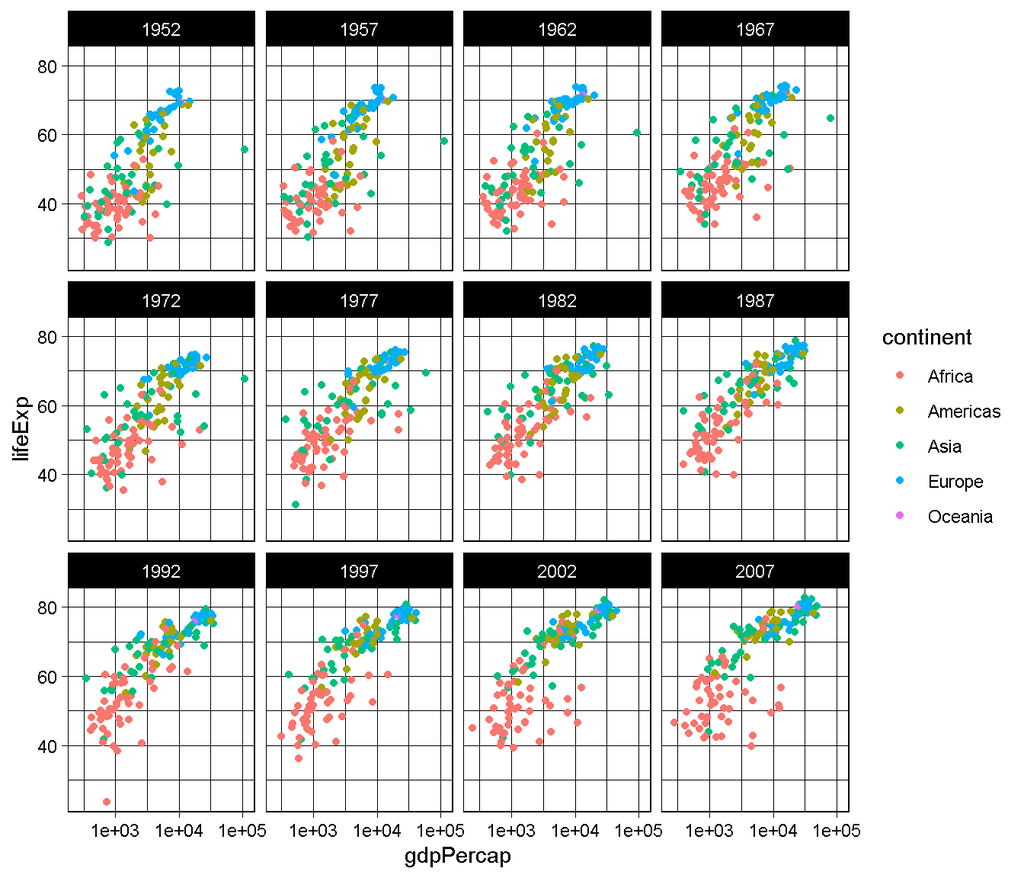

```r
p + geom_point(aes(colour = continent)) + scale_x_log10() +
    facet_wrap(~ year) +
  theme_linedraw()
```

O pacote `ggthemes()` oferece temas e escalas de cores adicionais. Mesmo gráfico com o tema `theme_igray()`.

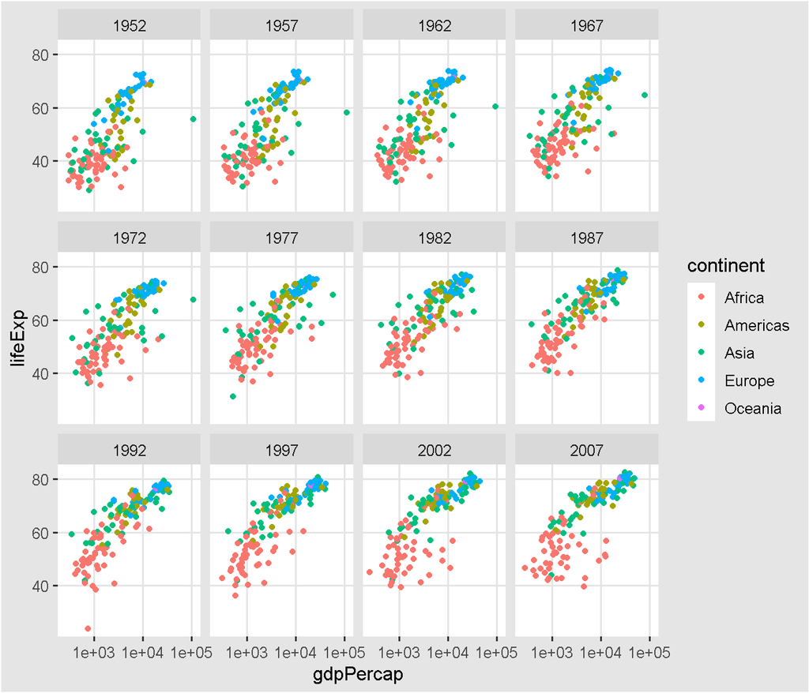

```r
library(ggthemes)
p + geom_point(aes(colour = continent)) + scale_x_log10() +
    facet_wrap(~ year) +
    theme_igray()
```

Idem, com o tema `theme_solarized_2()`.

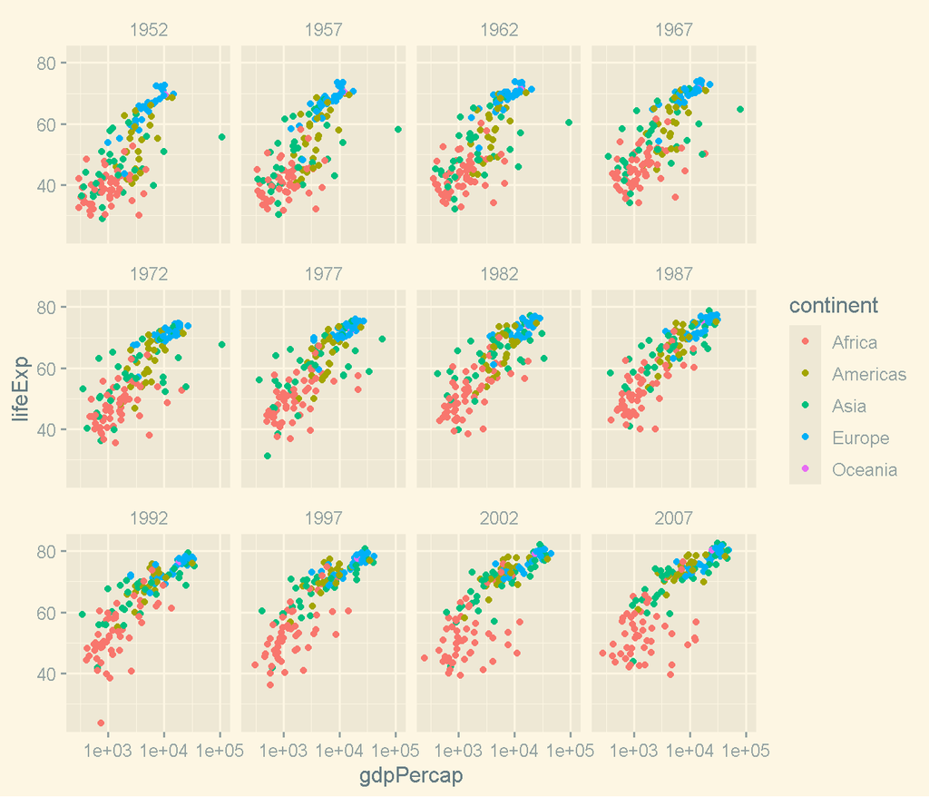

```r
library(ggthemes)
p + geom_point(aes(colour = continent)) + scale_x_log10() +
    facet_wrap(~ year) +
    theme_solarized_2()
```

Há várias opções de tema com as mais diversas finalidades. O tema `theme_karl()` (pacote `broman`), por exemplo, remove as marcas de escala e adiciona uma borda preta.

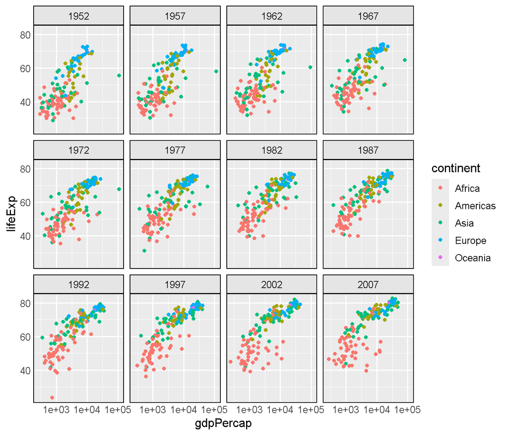

```r
library(broman)
p + geom_point(aes(colour = continent)) + scale_x_log10() +
    facet_wrap(~ year) +
    theme_karl()
```

#### Um exemplo de gráfico especial

Aproveitando-se do fato de o pacote `gapminder` incluir um objeto `country_colors` que possibilita colorir os países por tamanho de população e continente.

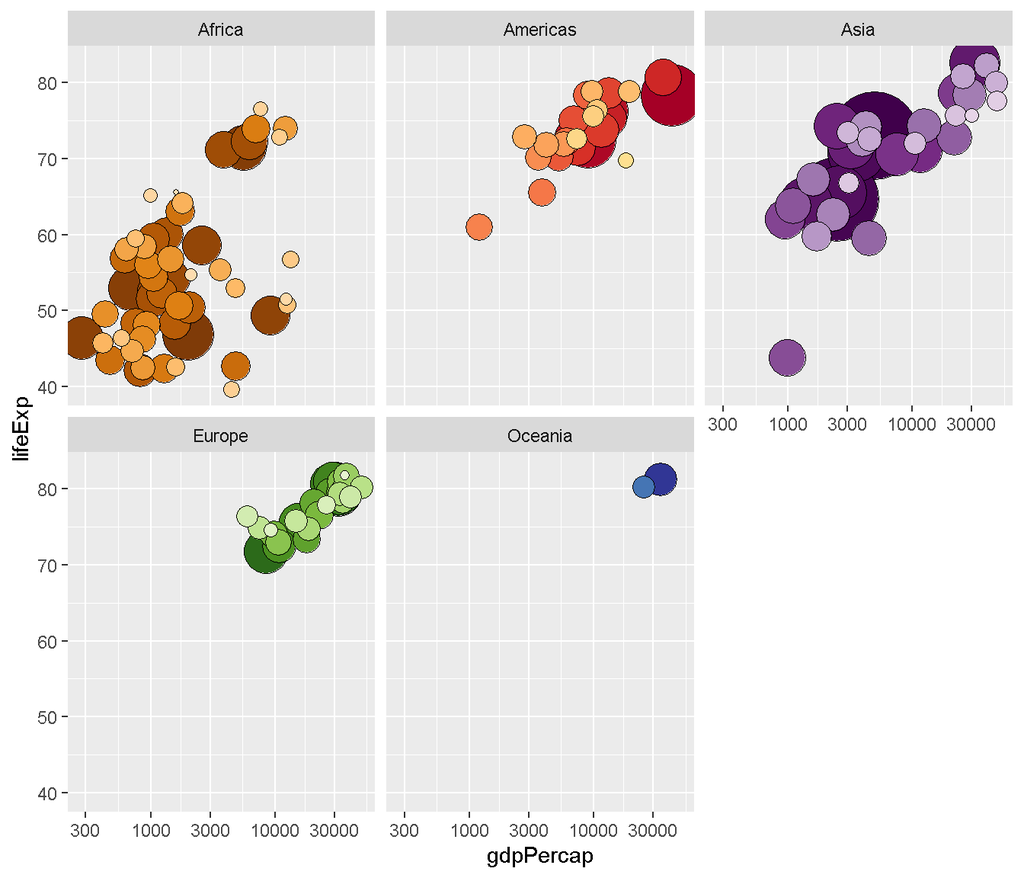

```r
    # Usando o objeto country_colors do pacote gapminder

  # subsetting por ano de 2007 e ordenando os dados por população
gm.2007 <- gapminder %>% filter(year==2007) %>% arrange(-pop)
  # gráfico faceado
ggplot(gm.2007, aes(y=lifeExp, x=gdpPercap, fill=country, size=sqrt(pop))) +
    geom_point(shape=21) +
    scale_x_log10() +
    scale_fill_manual(values=gapminder::country_colors) +
    facet_wrap(~continent) +
    scale_size_continuous(range=c(1, 20)) +
    guides(fill=FALSE, size=FALSE)
```

#### Commentários sobre os pacotes `ggplot2`e `lattice`:

- Estilo de Codificação:
  - `No`lattice, provavelmente será utilizada uma linha de código para especificar o tipo de gráfico que será plotado.
  - No `ggplot2` podem ser usadas quantas linhas se desejar para adicionar as configurações do gráfico.
- Resultado da figura:
  - O `lattice` produz gráficos simples, com melhores padrões melhores, sendo fáceis para exibir relacionamentos multivariáveis
  - O `ggplot2`permite adicionar muitas camadas na construção do gráfico, fazendo várias configurações de painel em cada uma delas. Isso possibilita a configuração de um gráfico complexo de várias camadas.

### Recomendação:

O pacote `ggplot2` é uma poderosa ferramenta para construção de gráficos. Aproveite esse estudo dirigido e pesquise bastante além do que está sugerido. A capacidade de apresentar visualmente explorações, análises e conclusões é uma habilidade importante para os profissionais de estatística. Você irá adquirir essa habilidade treinando bastante. Não hesitem em procurar-me caso tenham alguma dúvida sobre o conteúdo da disciplina.

*Divirtam-se!!!*.

## Relatório Técnico nº 1 - Construção de gráficos com o pacote `ggplot2`:

### Questões:

1. Adicionando texto a gráfico..
2. Construção de diagrama de dispersão.
3. Formato dos símbolos dos dados.
4. Atribuindo função `ggplot2` a objeto
5. Criando gráfico de área

### Instruções para entrega do trabalho

1. O trabalho deve ser entregue no Moodle até as 23h59 do dia 03/07/2024.
2. O trabalho deve ser elaborado em formato de relatório R Markdown, extensão .html, ou .pdf. Esse arquivo com a solução de sua atividade deverá ser denominado: 064-241_RT01-SEUNOME.html (ou .pdf).
3. Carregue o conjunto de dados `gapminder` e o pacote `ggplot2`, por meio dos comandos abaixo.

```r
library(gapminder)
library(ggplot2)
```

3. Não deixe de explorar e conhecer o conjunto de dados carregado.
4. É importante que você pesquise e estude cada comando novo que for apresentado nesse estudo dirigido

## Questão 1 - Adicionando texto a gráfico

O código a seguir produz painéis multiplos de expectativa de vida ao longo do tempo a partir do `gapminder`, com foco apenas nos países com nomes que começam com a letra “A” ou “Z”.

Inicialmente os dados são subdivididos (atividade de *subseting*). A função `substr` é usada para extrair uma parte de uma *string* (cadeia de caracteres), que extrai ou substitue *substrings* em um vetor de caracteres. Indica-se nesse caso, a posição inicial e final dos caracteres da *substring* desejada no vetor de países `gapminder$country`. O operador `%in%` permite fazer comparações múltiplas ao invés de escrever longas condições de *subsetting* (neste caso, `comeca.com %in% c("A", "Z")` é equivalente a `comeca.com == "A" | comeca.com == "Z"`). Execute o código abaixo e observe atentamente cada passo do procedimento efetuado, principalmente quanto aos comandos do pacote `ggplot2` com relação é construção dos gráficos e aos comandos novos de manipulação de *strings*. Acrescente uma camada por vez e compile os comandos para entender bem seu funcionamento.

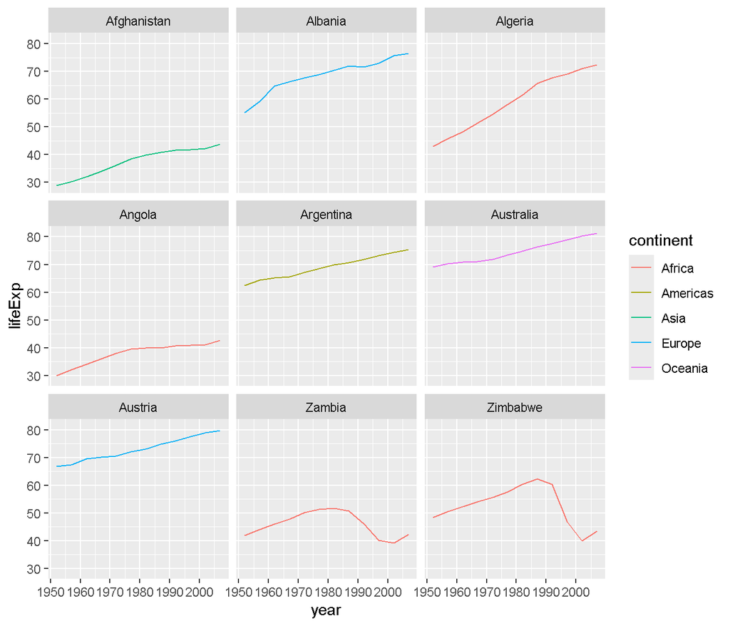

```r
comeca.com <- substr(gapminder$country, start = 1, stop = 1)
paises.az <- gapminder[comeca.com %in% c("A", "Z"), ]
ggplot(data = paises.az, aes(x = year, y = lifeExp, color = continent)) +
  geom_line() + facet_wrap( ~ country)
```

Para limpar essa figura é necessário alterar alguns dos elementos do texto. O eixo x é muito confuso e o nome do eixo y deve ser “Esperança de vida”, em vez do nome da variável do conjunto de dados.

Isso pode ser obtido adicionando-se algumas novas camadas. A camada *theme* controla o texto do eixo e seu tamanho. Há camadas especiais para alterar os rótulos dos eixos. Para alterar o título da legenda, precisamos usar a camada de escalas.

Defina “Figura 1” como título do gráfico, “Ano” como nome do eixo X, “Esperança de vida”, como nome do eixo y e “Continente”, como título da legenda. Use as seguintes funções para as definições solicitadas.

- Título: `ggtitle()`
- Nome do eixo x: `xlab()`
- Nome do eixo y: `ylab()`
- Título da legenda = `scale_colour_discrete ()`

```r
comeca.com <- substr(gapminder$country, start = 1, stop = 1)
paises.az <- gapminder[comeca.com %in% c("A", "Z"), ]
ggplot(data = paises.az, aes(x = year, y = lifeExp, color = continent)) +
  geom_line() + facet_wrap( ~ country)
# adicione seus comandos para os ajustes solicitados
```

## Questão 2 - Diagrama de dispersão

Use o conjunto de dados `mtcars`, com informações extraídas da revista *Motor Trend*, em 1974. Os dados compreendem o consumo de combustível e 10 aspectos do projeto e desempenho de 32 automóveis (modelos 1973-1974).

Crie um diagrama de dispersão que mostre a relação entre vários pesos de carro (`wt`), milhas por galão (`mpg`) e cilindros do motor (`cyl`). No gráfico, use pontos coloridos para mostrar as diferentes quantidades de cilindros. É necessária a conversão da variável `cyl` em um fator. Use a função `factor()` para essa finalidade.

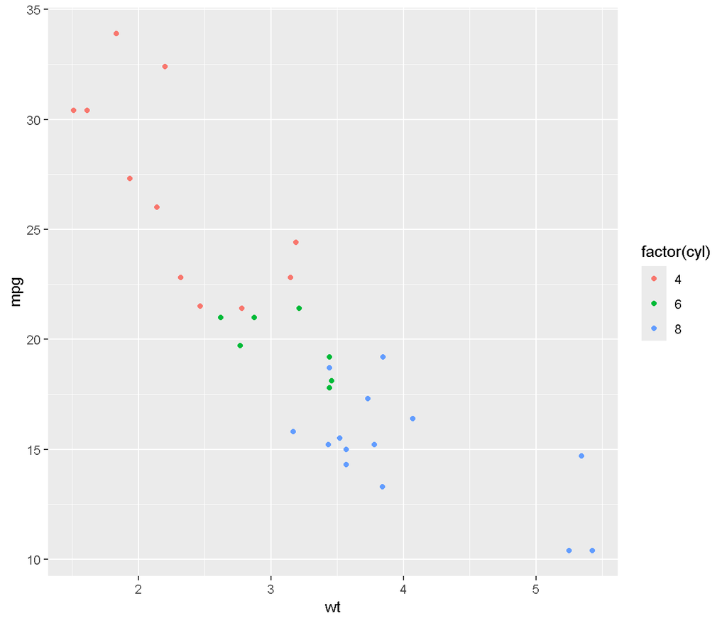

## Questão 3 - Formatos dos símbolos dos dados

Usando a solução do exemplo anterior, crie um novo gráfico usando os formatos dos símbolos dos dados para diferenciar as várias quantidades dos cilindros do motor.

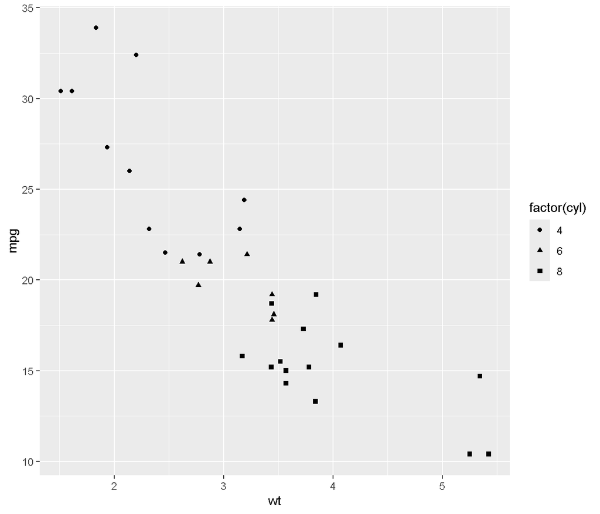

## Questão 4 - Atribuindo função `ggplot2`a objeto

Use o conjunto de dados `diamonds` para construir um diagrama de dispersão com a variável `carat`no eixo x e `price` no eixo y. Antes de prosseguir, pesquise sobre esse conjunto de dados e suas variáveis. O gráfico deve ser criado por meio de camadas obtidas por uma sequência de comandos em `ggplot2`. Atribua essa função ao objeto `meu.grafico`. Usando `+` adicione a função `geom_point()` com transparência `alpha = 0.1`. Adicione então `geom_smooth` e camada `theme_minimal` ao objeto `meu.grafico`. Mapeie a variável `clarity` ao argumento `color` da função `geom_smooth()` (ajuste `se = FALSE` para que não seja desenhada a região de confiança da estimativa suavizada). Perceba que o gráfico demorará alguns segundos para ser gerado.

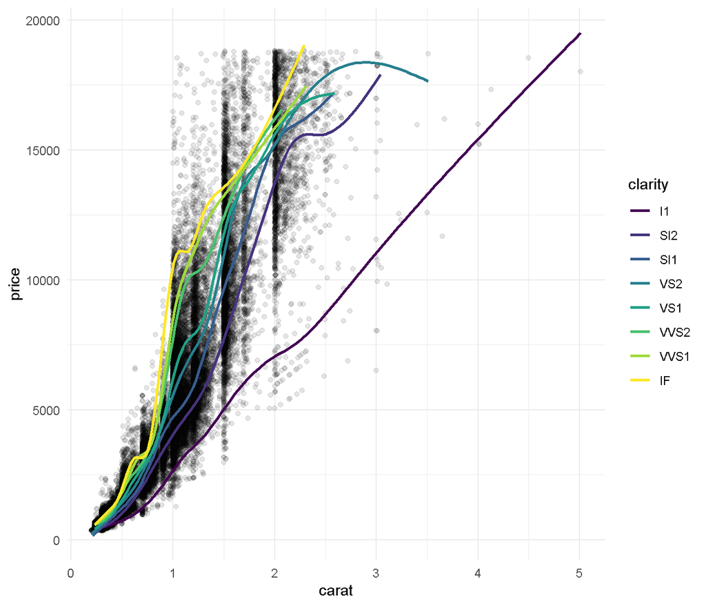

## Questão 5 - Criando gráfico de área

Use o conjunto de dados `gapminder` e crie gráficos de densidade da renda per capita (variável: `gdpPercap`), preenchido com cores de acordo com a variável `continent`. Para visualizar melhor a dispersão dos dados, aplique uma transformação `log10` no eixo x. Os gráficos deverão estar dispostos em painéis de acordo com os níveis da variável `year`. Sugestão: talvez as funções `facet_wrap` e `scale_x_*` possam ajudá-lo.

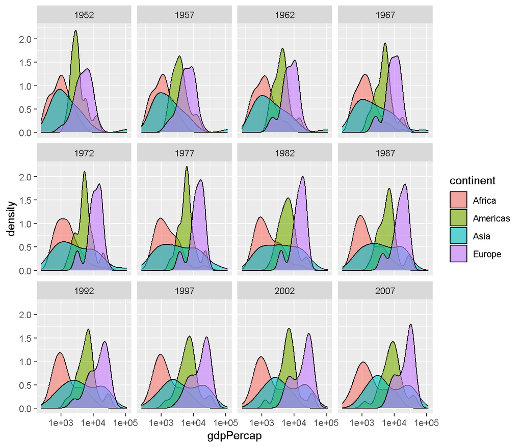